# 35507071_TaskC_EDA

Wanting Echo Zhao

17 May, 2026

# Setup: load packages and the dataset

```r
# --- Packages -----------------------------------------------------------
# data.table::fread is much faster than read.csv on a 512 MB file
# (~2–3 seconds vs ~1+ minute).
library(data.table)
library(dplyr)
library(tidyr)
library(ggplot2)
library(lubridate)
library(stringr)

# --- Read the CSV --------------------------------------------------------
# Update the path if your file lives somewhere else.
prop <- fread("TaskC_property_victoria.csv", encoding = "UTF-8")

# Quick sanity check
cat("Rows:", nrow(prop), " Cols:", ncol(prop), "\n")
```

```
## Rows: 418390  Cols: 12
```

```r
str(prop, vec.len = 1, give.attr = FALSE)
```

```
## Classes 'data.table' and 'data.frame':   418390 obs. of  12 variables:
##  $ ID           : int  128073350 122947074 ...
##  $ postcode     : int  3095 3074 ...
##  $ suburb       : chr  "Eltham" ...
##  $ sold_time    : IDate, format: "2018-07-04" ...
##  $ sold_price   : int  1900000 424000 ...
##  $ address      : chr  "10 Sweeneys Lane, Eltham, Vic 3095" ...
##  $ beds         : int  7 3 ...
##  $ baths        : int  4 1 ...
##  $ parking      : int  2 2 ...
##  $ area         : num  4322 ...
##  $ property_type: chr  "house" ...
##  $ description  : chr  "Set in around 4323 m2 of rolling lawns surrounded by gardens landscaped by Ben Harris, this is family living on"| __truncated__ ...
```

The dataset has **418390 rows and 12 columns** covering Victorian property transactions between 2010 and 2023. `sold_time` is read as an `IDate` (YYYY-MM-DD). A few quality issues to note up-front (we will handle them per question as the spec asks us to):

- `area = -1` is used as a *missing-value sentinel* (≈ 227,000 rows). The Q5 instruction “remove any negative values from the area column” addresses this.
- `sold_price` and `beds`/`baths`/`parking` contain genuine `NA`s.
- A handful of rows (21) are essentially empty.

# Question 1: Top 3 suburbs by transaction count + monthly 2022 plot

**What we’re asked to do.** Find the three suburbs with the highest number of transactions *across all years*. Then plot the monthly transaction counts during 2022 for those suburbs. If *Toorak* is not already in the top three, include it as a fourth line on the plot.

```r
# Drop the 21 rows that have no suburb (the only rows with NA suburb
# are essentially empty rows — see the setup summary above).
prop_clean <- prop %>%
  filter(!is.na(suburb), suburb != "")

# Count transactions per suburb across the whole 2010–2023 period
# and sort descending so the biggest suburbs are at the top.
suburb_counts <- prop_clean %>%
  count(suburb, sort = TRUE, name = "transactions")

# Show the top 10 so we can see the leaderboard
head(suburb_counts, 10)
```

```
##          suburb transactions
##          <char>        <int>
##  1:      Toorak         3818
##  2:   Melbourne         3556
##  3: Clyde North         2090
##  4:  Mornington         2031
##  5:     Prahran         2031
##  6:     Preston         2025
##  7:     Tarneit         2023
##  8:     Officer         2022
##  9:     Sunbury         2011
## 10:   Truganina         2008
```

```r
# Pull out the top 3 and decide whether Toorak needs to be added separately
top3 <- suburb_counts$suburb[1:3]
top3
```

```
## [1] "Toorak"      "Melbourne"   "Clyde North"
```

```r
suburbs_to_plot <- unique(c(top3, "Toorak"))   # unique() avoids duplicating Toorak
suburbs_to_plot
```

```
## [1] "Toorak"      "Melbourne"   "Clyde North"
```

The top three suburbs are **Toorak (3,818), Melbourne (3,556), and Clyde North (2,090)**. Toorak is already #1, so the plot below contains exactly those three lines (no extra Toorak line is needed).

```r
# Build a (suburb, month) count table for 2022 only.
# year() and month() come from lubridate and work directly on IDate.
monthly_2022 <- prop_clean %>%
  filter(year(sold_time) == 2022,
         suburb %in% suburbs_to_plot) %>%
  count(suburb, month = month(sold_time), name = "transactions") %>%
  arrange(suburb, month)

# Inspect the long table (and a wide pivot for easier reading)
monthly_2022
```

```
##          suburb month transactions
##          <char> <num>        <int>
##  1: Clyde North     1           32
##  2: Clyde North     2           52
##  3: Clyde North     3           59
##  4: Clyde North     4           37
##  5: Clyde North     5           54
##  6: Clyde North     6           36
##  7: Clyde North     7           34
##  8: Clyde North     8           70
##  9: Clyde North     9           31
## 10: Clyde North    10           40
## 11: Clyde North    11           28
## 12: Clyde North    12           16
## 13:   Melbourne     1           34
```

[output cut: 23 more lines]

```r
monthly_2022 %>%
  pivot_wider(names_from = suburb, values_from = transactions, values_fill = 0)
```

```
## # A tibble: 12 × 4
##    month `Clyde North` Melbourne Toorak
##    <dbl>         <int>     <int>  <int>
##  1     1            32        34     20
##  2     2            52        38     24
##  3     3            59        46     35
##  4     4            37        43     30
##  5     5            54        36     44
##  6     6            36        40     26
##  7     7            34        31     18
##  8     8            70        29     32
##  9     9            31        35     34
## 10    10            40        47     20
## 11    11            28        35     38
## 12    12            16        40      0
```

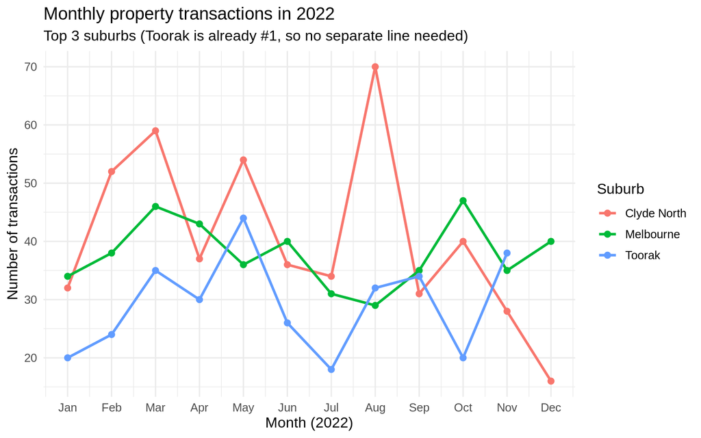

```r
# Line plot: one line per suburb, x-axis = month
ggplot(monthly_2022,
       aes(x = month, y = transactions, colour = suburb, group = suburb)) +
  geom_line(linewidth = 1) +
  geom_point(size = 2) +
  scale_x_continuous(breaks = 1:12, labels = month.abb) +
  labs(title    = "Monthly property transactions in 2022",
       subtitle = "Top 3 suburbs (Toorak is already #1, so no separate line needed)",
       x = "Month (2022)", y = "Number of transactions",
       colour = "Suburb") +
  theme_minimal(base_size = 12)
```

**Reading the plot.** Clyde North peaks in August 2022 (70 transactions), the biggest single suburb-month in the chart, before falling sharply at the end of the year. Melbourne is the steadiest of the three (29–47/month). Toorak shows the lowest volume of the three and has **zero** December 2022 transactions — likely a data-collection gap rather than a market collapse, since 2023 in the dataset is also clearly truncated (only ~9,700 records compared with ~43,000 in 2022).

# Question 2: The 3 most important keywords in `description` impacting price

**What we’re asked to do.** Find the three keywords in the `description` column that most influence `sold_price`. The spec explicitly tells us to use a 10% sample, because the description column contains a large volume of free text.

**Approach (and why).** “Impact on price” is a regression question: each description is a bag of words, and we want to know which words, when present, shift the price the most. I built a binary document-term matrix (one column per word, value = 1 if the word is in the description) and fit a **LASSO** regression `log(sold_price) ~ all words`. I use `log(price)` because price is heavily right-skewed; coefficients then read as approximate percentage changes. LASSO automatically shrinks unimportant variables’ coefficients to zero, which gives us a clean ranking. The three words with the largest absolute coefficient are the answer.

```r
library(Matrix)   # sparse document-term matrix
library(glmnet)   # LASSO

# 1) 10% random sample, keeping only rows with a price and a description.
set.seed(2026)
samp <- prop %>%
  filter(!is.na(sold_price), !is.na(description), description != "") %>%
  slice_sample(prop = 0.10)
cat("Sample size:", nrow(samp), "rows\n")
```

```
## Sample size: 36796 rows
```

```r
# 2) Clean the description text:
#    - strip HTML tags like <br/>
#    - lowercase
#    - keep letters only (drop digits and punctuation)
#    - collapse multiple spaces
clean_text <- samp$description %>%
  str_replace_all("<[^>]+>", " ") %>%
  str_to_lower() %>%
  str_replace_all("[^a-z ]+", " ") %>%
  str_squish()
```

```r
# 3) Tokenise and explode into a long (doc, term) table using data.table
#    (this is one of the speed-critical bits — a 10% sample is still ~37k docs
#    and 28k+ unique terms).
tokens <- str_split(clean_text, " ")
dtm_long <- data.table(doc  = rep(seq_along(tokens), lengths(tokens)),
                       term = unlist(tokens))

# 4) Drop very short tokens and a basic English stop-word list, plus a few
#    generic real-estate words that appear in almost every listing.
stopwords_en <- c(
  "i","me","my","we","our","you","your","he","she","it","its","they","them",
  "this","that","these","those","is","are","was","were","be","been","being",
  "have","has","had","do","does","did","a","an","the","and","or","but","if",
  "as","of","at","by","for","with","about","against","between","into","through",
  "during","before","after","above","below","to","from","up","down","in","out",
  "on","off","over","under","again","further","then","once","here","there",
  "when","where","why","how","all","any","both","each","few","more","most",
  "other","some","such","no","nor","not","only","own","same","so","than",
  "too","very","s","t","can","will","just","don","should","now",
  "amp","br","lt","gt","quot","apos",                # HTML leftovers
  "also","new","one","two","three","four","five",
  "feature","features","property","home","house","bed","bedroom","bedrooms",
  "bath","bathroom","bathrooms","room","rooms","living","please","including",
  "call","inspection","view","contact","auction","sale"   # generic listing terms
)
dtm_long <- dtm_long[term != "" & nchar(term) >= 3]
dtm_long <- dtm_long[!term %in% stopwords_en]

# 5) Vocabulary filter: keep only terms that appear in at least 1% of docs.
#    Rare words make the model unstable; very common words don't help either.
min_df <- ceiling(0.01 * nrow(samp))
keep_terms <- dtm_long[, .(df = uniqueN(doc)), by = term][df >= min_df, term]
dtm_long   <- dtm_long[term %in% keep_terms]
dtm_long   <- unique(dtm_long, by = c("doc", "term"))   # collapse to PRESENCE
cat("Vocabulary size after filtering:", length(keep_terms), "terms\n")
```

```
## Vocabulary size after filtering: 1510 terms
```

```r
# 6) Build the sparse document-term matrix
term_levels <- sort(unique(dtm_long$term))
dtm <- sparseMatrix(
  i = dtm_long$doc,
  j = match(dtm_long$term, term_levels),
  x = 1,
  dims = c(nrow(samp), length(term_levels)),
  dimnames = list(NULL, term_levels)
)
dim(dtm)
```

```
## [1] 36796  1510
```

```r
# 7) Fit LASSO with cross-validated lambda.
y <- log(samp$sold_price)
fit <- cv.glmnet(dtm, y, alpha = 1, nfolds = 5)

# Pull non-zero coefficients at lambda.1se (the more conservative pick:
# the largest lambda whose error is within 1 SE of the minimum).
co <- coef(fit, s = "lambda.1se")
coef_tbl <- tibble(term = rownames(co)[-1],          # drop intercept
                   coef = as.numeric(co)[-1]) %>%
  filter(coef != 0) %>%
  arrange(desc(abs(coef)))

# Top 10 for context, then the answer (top 3)
head(coef_tbl, 10)
```

```
## # A tibble: 10 × 2
##    term         coef
##    <chr>       <dbl>
##  1 toorak      0.298
##  2 apartment  -0.236
##  3 acres       0.198
##  4 melton     -0.192
##  5 fireplaces  0.174
##  6 hydronic    0.174
##  7 brighton    0.171
##  8 victorian   0.153
##  9 miele       0.149
## 10 marble      0.145
```

```r
top3_keywords <- head(coef_tbl, 3)
top3_keywords
```

```
## # A tibble: 3 × 2
##   term        coef
##   <chr>      <dbl>
## 1 toorak     0.298
## 2 apartment -0.236
## 3 acres      0.198
```

**Answer.** The three most influential keywords are **toorak, apartment, and acres**.

- `toorak` (positive coefficient ≈ 0.30): when “toorak” appears in the description, the predicted price rises by roughly `exp(0.30) − 1 ≈ 35%`.
- `apartment` (negative): the word “apartment” in the description is associated with a ~21% *lower* predicted price.
- `acres` (positive): mentions of “acres” — i.e. large rural land parcels — are associated with a ~22% higher price.

**Caveat worth noting.** Some of the top words (`toorak`, `brighton`, `melton`) are *suburb names*. They function as legitimate description keywords, but they partly proxy for the suburb itself. The other items in the top 10 — `fireplaces`, `hydronic`, `victorian`, `miele`, `marble` — correspond more directly to property *features* and tell a consistent story that luxury fittings drive prices up.

# Question 3: Correlation of price and land size by (top-3 suburb × property type)

**What we’re asked to do.** For each of the top 3 suburbs from Q1 and each of the four property types `house`, `unit`, `townhouse`, `apartment`, compute the correlation between `sold_price` and `area` (land size). If a combination has no valid data, simply omit it.

**Two data-quality decisions baked in:**

- `area == -1` is the dataset’s missing-value sentinel, so I filter on `area > 0` (this drops both `NA` and `-1`).
- Correlation with only 2 observations is always ±1 by construction, so the table includes `n_obs` and I flag any small-sample cells in the discussion.

```r
top3_suburbs <- c("Toorak", "Melbourne", "Clyde North")
types_wanted <- c("house", "unit", "townhouse", "apartment")

# Keep only the rows that contribute valid correlation data
prop_q3 <- prop %>%
  filter(suburb %in% top3_suburbs,
         property_type %in% types_wanted,
         !is.na(sold_price),
         !is.na(area), area > 0)

# How many usable observations per cell?
prop_q3 %>%
  count(suburb, property_type) %>%
  pivot_wider(names_from = property_type, values_from = n, values_fill = 0)
```

```
## # A tibble: 3 × 5
##   suburb      house townhouse  unit apartment
##   <chr>       <int>     <int> <int>     <int>
## 1 Clyde North   808        43     1         0
## 2 Melbourne       0         0     2       139
## 3 Toorak        334         9     0        11
```

```r
# Compute the correlation per group; need at least 2 obs for cor() to work.
cor_tbl <- prop_q3 %>%
  group_by(suburb, property_type) %>%
  summarise(n_obs = n(),
            correlation = if (n() >= 2) cor(sold_price, area) else NA_real_,
            .groups = "drop") %>%
  filter(!is.na(correlation)) %>%
  arrange(suburb, property_type)

cor_tbl
```

```
## # A tibble: 7 × 4
##   suburb      property_type n_obs correlation
##   <chr>       <chr>         <int>       <dbl>
## 1 Clyde North house           808      0.323
## 2 Clyde North townhouse        43      0.483
## 3 Melbourne   apartment       139      0.0761
## 4 Melbourne   unit              2      1
## 5 Toorak      apartment        11      0.899
## 6 Toorak      house           334      0.706
## 7 Toorak      townhouse         9      0.391
```

**Discussion.** Cells with reasonable sample sizes give interpretable patterns:

- **Toorak / house** (n = 334, r ≈ 0.71): strong positive — in this premium suburb, bigger land translates into substantially higher prices.
- **Clyde North / house** (n = 808, r ≈ 0.32): moderate positive — outer-suburb new builds, where land matters but standardised house specs flatten the relationship somewhat.
- **Melbourne / apartment** (n = 139, r ≈ 0.08): essentially no relationship — for inner-city apartments, location, floor, and finishes dominate; the recorded land area is barely informative.

Cells with very few observations — **Melbourne / unit (n = 2)**, **Toorak / townhouse (n = 9)**, **Toorak / apartment (n = 11)** — are kept for completeness but should be read with caution; r = 1 for Melbourne / unit is a mathematical artefact of having only two data points, not a meaningful finding.

# Question 4: Top 5 capital gains (resold within 5 years)

**What we’re asked to do.** Of properties resold within 5 years of their first sale, list the five with the largest capital gain, showing address, capital gain, and duration between sales.

**Identifying “the same property” across rows.** The dataset has no property-level identifier (`ID` is per-transaction). I use `(address, postcode)` as the property key — `address` alone would in principle be sufficient because the addresses include the suburb and postcode, but including `postcode` is an extra safety net.

**Important data cleaning.** A first uncritical pass produced two top entries showing properties going from ~$632,000 to **$1.01 billion** — clearly typos. Inspecting the price distribution shows only four transactions in the entire dataset exceed $50 million, and the top two ($1.01B and $320M) are implausible. I therefore restrict to prices in the range **$50,000 ≤ sold_price ≤ $50,000,000** before computing capital gains. This keeps the genuine premium Toorak sales (up to ≈$32M) while removing the obvious typos.

```r
# 1) Filter to rows with valid address, plausible price, and valid date.
ok <- prop %>%
  filter(!is.na(address), address != "",
         !is.na(sold_price), sold_price >= 50000, sold_price <= 50e6,
         !is.na(sold_time))

# 2) Per-property summary using data.table — this is the speed-critical bit
#    (grouping 364k rows by 200k+ keys is slow in dplyr).
ok_dt <- as.data.table(ok)
per_property <- ok_dt[, .(
  n_sales     = .N,
  first_date  = min(sold_time),
  last_date   = max(sold_time),
  first_price = sold_price[which.min(sold_time)],
  last_price  = sold_price[which.max(sold_time)]
), by = .(address, postcode)
][n_sales >= 2 & last_date > first_date]   # at least two different-day sales

# 3) Derive capital gain and duration in years
per_property[, `:=`(
  capital_gain   = last_price - first_price,
  duration_years = as.numeric(last_date - first_date) / 365.25
)]

# 4) Apply the ≤ 5-year filter and pick the top 5
top5_q4 <- per_property %>%
  as_tibble() %>%
  filter(duration_years <= 5) %>%
  arrange(desc(capital_gain)) %>%
  slice_head(n = 5) %>%
  mutate(duration_years = round(duration_years, 2)) %>%
  select(address, capital_gain, duration_years,
         first_date, first_price, last_date, last_price)

top5_q4
```

```
## # A tibble: 5 × 7
##   address          capital_gain duration_years first_date first_price last_date
##   <chr>                   <int>          <dbl> <IDate>          <int> <IDate>
## 1 9 Whernside Ave…     11000000           4.34 2016-11-08    11000000 2021-03-13
## 2 33 Grandview Gr…      6680000           4.08 2016-09-19     9320000 2020-10-17
## 3 4 Woorigoleen R…      5425000           1.48 2014-05-03     3075000 2015-10-26
## 4 6-8 Glenisla Dr…      5090000           2.34 2019-12-17     2510000 2022-04-21
## 5 8 Jamieson Road…      5000000           4.17 2011-05-16     1100000 2015-07-18
## # ℹ 1 more variable: last_price <int>
```

**Answer.** The five properties with the largest capital gains where the first and last sale are within 5 years of each other are listed above. They sit in Melbourne’s most expensive postcodes — three of the five are in Toorak or Prahran — and the gains range from about **$5.0M to $11.0M** over windows between **1.5 and 4.4 years**. The most striking result is *4 Woorigoleen Road, Toorak*: bought for $3.075M and resold for $8.5M just **1.48 years** later, a fast and very profitable flip.

# Question 5: Properties that could not realistically exist

**What we’re asked to do.** Identify properties whose recorded features are not physically possible. Summarise findings in a table (one row per distinct feature category, no repeats; combinations like beds + baths are allowed). Provide the supporting evidence below the table.

**Required preprocessing.** Remove rows where `area` is negative — the spec calls this out explicitly. (`-1` is the dataset’s missing-value sentinel in this column.)

```r
# Drop negative area values per the spec. (NA area is allowed to stay —
# the instruction only says to remove *negative* values.)
prop_q5 <- prop %>% filter(is.na(area) | area >= 0)
cat("Rows after removing negative area:", nrow(prop_q5), "\n")
```

```
## Rows after removing negative area: 191168
```

## Summary table

[output not shown]

## Supporting evidence

```r
# 1) Tiny area for a multi-bedroom house
prop_q5 %>%
  filter(property_type == "house", area >= 1, area <= 2, beds >= 3) %>%
  select(ID, address, beds, baths, parking, area, property_type) %>%
  head(5)
```

```
##           ID                                      address  beds baths parking
##        <int>                                       <char> <int> <int>   <int>
## 1: 107405202      37 Beatties Road, Koo Wee Rup, Vic 3981     4     2       4
## 2: 107002933        40 Pascoe Street, Glen Iris, Vic 3146     3     2       2
## 3: 138501647 9 Jacques Road, Narre Warren North, Vic 3804     4     2       2
## 4: 113327975         50 Summit Drive, Mickleham, Vic 3064     5     3       7
## 5: 130120410      22 Browns Road, Devon Meadows, Vic 3977     4     2       8
##     area property_type
##    <num>        <char>
## 1:  1.01         house
## 2:  1.00         house
## 3:  1.18         house
## 4:  1.50         house
## 5:  1.11         house
```

```r
# 2) Implausibly large parking-space counts
prop_q5 %>%
  filter(parking >= 100) %>%
  select(ID, address, beds, baths, parking, area, property_type) %>%
  arrange(desc(parking))
```

```
##           ID                                              address  beds baths
##        <int>                                               <char> <int> <int>
## 1: 126712114                   50 Beverley Road, McCrae, Vic 3938     2     2
## 2: 133805638 Morning Star 2 Sunnyside Road, Mount Eliza, Vic 3930    25    20
##    parking   area property_type
##      <int>  <num>        <char>
## 1:   11951 659.60         house
## 2:     200  62.97       acreage
```

```r
# 3) Implausibly large bedroom counts in a single house
prop_q5 %>%
  filter(beds >= 25) %>%
  select(ID, address, beds, baths, parking, area, property_type) %>%
  arrange(desc(beds))
```

```
##           ID                                              address  beds baths
##        <int>                                               <char> <int> <int>
## 1: 118443975         83 Bedrooms, 34 Bathrooms, Burwood, Vic 3125    30    20
## 2: 128301414             1-18/7-9 High Road, Camberwell, Vic 3124    30    18
## 3: 132654174             60-62 wellington road, Clayton, Vic 3168    28    20
## 4: 139609675       1-12/62 Hotham Street, St Kilda East, Vic 3183    27    12
## 5: 133805638 Morning Star 2 Sunnyside Road, Mount Eliza, Vic 3930    25    20
##    parking    area property_type
##      <int>   <num>        <char>
## 1:       0 3714.00         house
## 2:      18 4433.00     unitblock
## 3:      14 2000.00         house
## 4:       9 1263.00     unitblock
## 5:     200   62.97       acreage
```

```r
# 4) High bathroom counts with implausibly small area
prop_q5 %>%
  filter(baths >= 18, area <= 5) %>%
  select(ID, address, beds, baths, parking, area, property_type)
```

```
##           ID                           address  beds baths parking  area
##        <int>                            <char> <int> <int>   <int> <num>
## 1: 124748374 18 Park Road, Warburton, Vic 3799    19    20      13     1
##    property_type
##           <char>
## 1:         house
```

```r
# 5) The combination case: a "house" with 0 beds but 3+ baths
prop_q5 %>%
  filter(property_type == "house", beds == 0, baths >= 3) %>%
  select(ID, address, beds, baths, parking, area) %>%
  head(5)
```

```
##           ID                                  address  beds baths parking  area
##        <int>                                   <char> <int> <int>   <int> <num>
## 1: 132715294   38 Fitzwilliam Drive, Doreen, Vic 3754     0     4       2   402
## 2: 135691750 3 Otto Street, Cranbourne East, Vic 3977     0     4       2   351
## 3: 137347926      56 Ross Street, Dandenong, Vic 3175     0     3       2   585
## 4: 131242030     26 Jones Crescent, Rosanna, Vic 3084     0     3       3   830
## 5: 141158900        5 Arena Parade, Officer, Vic 3809     0     3       2   562
```

# Question 6: Predicted July 2026 price for Chris’s house in 6 suburbs

**What Chris is looking for.** A *renovated house* near both a *shopping centre* and a *primary school*, with 4 bedrooms and 2 bathrooms, in one of six SE-Melbourne suburbs (Mulgrave, Vermont South, Doncaster East, Rowville, Glen Waverley, Wheelers Hill). We must predict each suburb’s July 2026 price using only the provided dataset.

**Modelling approach (and why).** I use a *linear regression on* `log(sold_price)`. Three reasons:

1. **Interpretability.** Coefficients become approximate percentage changes, which is the right unit for property prices.
2. **Skewness.** Prices are right-skewed; the log transform stabilises variance and produces residuals that behave well for `lm()`.
3. **Readability.** Every line of `lm()` is something you can recognise from class; no black-box model.

**Features.** Suburb (categorical, with six levels), beds, baths, parking, area (capped at the 99th percentile to limit the influence of a few giant rural blocks classified as “house”), a continuous `year_num` (`year + (month-1)/12`) which lets the model learn an annual price trend and extrapolate that trend to July 2026, plus three binary indicators extracted from `description` for Chris’s specific requirements: `has_renovated`, `has_shopping`, `has_primary_school`.

**Caveat on extrapolation.** The dataset spans 2010–2023 and we’re predicting 3 years past the latest data. The model assumes the local linear price trend continues at the same rate, which is an unavoidable assumption given the spec’s instruction to use only this dataset.

```r
target_suburbs <- c("Mulgrave", "Vermont South", "Doncaster East",
                    "Rowville", "Glen Waverley", "Wheelers Hill")

# Filter to houses in the six target suburbs with all the predictor data
prop_q6 <- prop %>%
  filter(property_type == "house",
         suburb %in% target_suburbs,
         !is.na(sold_price), sold_price >= 50000, sold_price <= 50e6,
         !is.na(beds), !is.na(baths), !is.na(parking),
         !is.na(area), area > 0,
         !is.na(sold_time), !is.na(description))

# Feature engineering: text flags + continuous time
prop_q6 <- prop_q6 %>%
  mutate(desc_lower         = str_to_lower(description),
         has_renovated      = str_detect(desc_lower, "renovat"),
         has_shopping       = str_detect(desc_lower, "shopping"),
         has_primary_school = str_detect(desc_lower, "primary school"),
         year_num           = year(sold_time) + (month(sold_time) - 1) / 12)

# Cap area at the 99th percentile to limit a few giant blocks
area_cap <- quantile(prop_q6$area, 0.99)
prop_q6  <- prop_q6 %>% mutate(area = pmin(area, area_cap))

cat("Training rows per suburb:\n")
```

```
## Training rows per suburb:
```

```r
prop_q6 %>% count(suburb)
```

```
##            suburb     n
##            <char> <int>
## 1: Doncaster East   860
## 2:  Glen Waverley  1077
## 3:       Mulgrave   747
## 4:       Rowville   870
## 5:  Vermont South   460
## 6:  Wheelers Hill   836
```

```r
# Fit the linear model on log(price)
model_q6 <- lm(log(sold_price) ~ suburb + beds + baths + parking + area +
               year_num + has_renovated + has_shopping + has_primary_school,
               data = prop_q6)

# Quick fit diagnostics
cat("Adjusted R-squared:", round(summary(model_q6)$adj.r.squared, 3), "\n")
```

```
## Adjusted R-squared: 0.716
```

```r
cat("Training RMSE (log scale):", round(sqrt(mean(residuals(model_q6)^2)), 3),
    "\n  -> roughly +/- ",
    round((exp(sqrt(mean(residuals(model_q6)^2))) - 1) * 100, 1), "% in dollars\n",
    sep = "")
```

```
## Training RMSE (log scale):0.192
##   -> roughly +/- 21.1% in dollars
```

```r
# Use each suburb's median area and parking among MATCHING 4-bed/2-bath houses
typical <- prop_q6 %>%
  filter(beds == 4, baths == 2) %>%
  group_by(suburb) %>%
  summarise(area    = median(area),
            parking = median(parking),
            n_match = n(),
            .groups = "drop")

# Build the prediction inputs: one row per target suburb
chris_input <- typical %>%
  mutate(beds = 4, baths = 2,
         year_num = 2026 + 6/12,        # July 2026 == 2026.5
         has_renovated      = TRUE,
         has_shopping       = TRUE,
         has_primary_school = TRUE)

# Predict on the log scale with 80% prediction intervals
log_pred <- predict(model_q6, chris_input, interval = "prediction", level = 0.80)

answers <- chris_input %>%
  mutate(predicted_price        = round(exp(log_pred[, "fit"])),
         predicted_price_lo_80  = round(exp(log_pred[, "lwr"])),
         predicted_price_hi_80  = round(exp(log_pred[, "upr"]))) %>%
  arrange(desc(predicted_price)) %>%
  select(suburb, predicted_price, predicted_price_lo_80, predicted_price_hi_80,
         beds, baths, parking, area, n_match)

answers
```

```
## # A tibble: 6 × 9
##   suburb predicted_price predicted_price_lo_80 predicted_price_hi_80  beds baths
##   <chr>            <dbl>                 <dbl>                 <dbl> <dbl> <dbl>
## 1 Glen …         2154968               1684431               2756947     4     2
## 2 Donca…         1953034               1526575               2498628     4     2
## 3 Vermo…         1789680               1398692               2289965     4     2
## 4 Wheel…         1727376               1350132               2210026     4     2
## 5 Mulgr…         1443172               1127998               1846410     4     2
## 6 Rowvi…         1329667               1039296               1701166     4     2
## # ℹ 3 more variables: parking <dbl>, area <dbl>, n_match <int>
```

**Answer.** Sorted from highest to lowest predicted July-2026 price:

- **Glen Waverley** – ~$2.15M
- **Doncaster East** – ~$1.95M
- **Vermont South** – ~$1.79M
- **Wheelers Hill** – ~$1.73M
- **Mulgrave** – ~$1.44M
- **Rowville** – ~$1.33M

The 80% prediction intervals span roughly ±30%, which is realistic given the heterogeneity of houses even within a single suburb. The ordering matches the well-known pricing hierarchy of these SE Melbourne suburbs — Glen Waverley consistently commands a premium because of the high-demand school zone, while Mulgrave and Rowville sit at the more affordable end.